# The meta-analysis

by Jens

Sorry about the bad layout, I'm new to R presentations

### Content

- What is a meta-analysis, why do we need it?
- approach and differences to experiments
- hypothesis
- study design
- scoping [exercise]
- data extraction [exercise]
- analysis

### What is a meta-analysis

- A special version of a **review**
- A review is the *synthesis* and *critical appraisal* of existing studies
  - **narrative** (based on expert opinion a.k.a. papers in your library, e.g. TREE) or **systematic** (structured search):
    - **qualitative** (classical review) or **quantitative** (aka meta-analysis)
- It is not a review if it does not critically appraise studies (vote-counts, counting studies with effect vs studies without effect)

### Why do we need meta-analyses?

- conflicting results depending on particularities of study system or region
- underpowered studies
- publication bias
- test new hypotheses

### Who should do meta-analyses?

- everyone! It changes the way we view science:
  - away from text-book examples to incremental knowledge increase
  - (im-) proper reporting standards
    - “40-120 individuals per treatment”
    - “Locations: Onishica (ON: 44°1O'N, 30 m)”
  - open science and transparency
- but not without some introduction
  - many (MANY) meta-analyses are shoddy

### How to do a meta-analysis

1. The hypothesis
2. Study design (search strategy, extraction and analysis)
3. Pre-registering
4. collect data
5. Analysis (weighted by reliability)
6. Write and submit

### Differences to experiments

- larger datasets
- multiple sources and data formats
- costly (requires a lot of time)
- gets a lot of attention (citations)
- “negative” results are okay(ish)

### Differences (2)

- synthesis may affect policies etc -> requires extra rigour
- multiple decisions that require expert opinion -> need to be objective
- meta-analysis may be updated after a few years, or replicated by someone else -> need to be transparent (open)

### 1. The hypothesis

- answerable
- not answered yet
- PICO: Population, Intervention/Exposure, Comparator, Outcome
- e.g. “is poison-baiting effective at eradicating rats from islands”  
  **example: “Does beetle size increase with mean annual temperature?”**

### 2. Study design: Search strategy

**“Does beetle size vary with temperature?”**

- identify search strategy - this defines sample size!
  - web of science, “(coeloptera OR beetle) AND size AND temperat*”
  - google for grey literature, but not standard literature (no transparency or reproducibility)
  - will give irrelevant and potentially relevant studies, filter by title

### 2. Study design: Inclusion criteria

- formulate inclusion criteria - this defines bias and heterogeneity in studies!
  - only lab studies
  - either multiple sites or long-term data on single site (5 minimum)

### 2. Study design: Data extraction

- formulate rules for data extraction - this is pretty much standardised
  - raw data (body size in mm) or mean + s.e. , annual mean temperature

### 2. Study design: Analysis

- formulate analysis approach - this is also standardized
  - linear mixed-effects model with log(body size) ~ annual mean temperature, random = study, weight = 1/s.e.

### 3. Study design: Scoping [exercise]

- do a pilot experiment - “scoping”
- Try playing around with search terms in web of science! check results of **“(coleoptera OR beetle) AND size AND temperat*”** and try to improve it
  - many relevant studies
  - few false positives

My own meta-analysis (differnt topic) had 1641 results in web of science, 300 seemed relevant, and 30 were included (1:50)  
Recent Ecology Letters meta-analysis: 27.854 results, 192 studies (1:150)

### Tips

- titles often tell not much (e.g. 26 entries of “winter is coming”) - “topic” is better (title + keywords + abstract)  
  ___________________
- useful operators “x AND (y OR z) NOT "bill gates”
- wildcards: *ldcar*, flavo$r", “organi?ation”
- quotation marks: **robber fly** finds “pollen robber and syrphid fly”, **“robber fly”** does not
- lemmatization: **range expansion** will find “Effective expansion of satellite laser ranging network”, but **“range” expansion** does not)  
  ____________
- use forward citation and check why relevant articles were not found
- if you find an older meta-analysis, your search should find at least all articles they found
- no need to find ALL studies, but aim for around 20 studies

### own example

**search term** **TS** = ((“day length” **OR** photoperiod* **OR** diapaus* **OR** hibern* **OR** dorman* ) **AND** (geogr* **OR** “range” **OR** latitud* **OR** longitud*) (7500) results

**strategy**  
#2 **#1 AND SU** = “Entomology”

#3 **#1 NOT #2 AND SU =** “Zoology” **AND TI** = (centipede* **OR** collembol* **OR** insect$ **OR** *PTERA [x50])

#4 […] **NOT** **SU =**[vertebrate taxa] [similar stuff for plant journals and ecology]

#16: **#14 NOT #15 NOT TI =** (human **OR** sleep* **OR** disorder **OR** depress* **OR** marine* **OR** […] **OR** palaeo* **OR** $vertebra* […] **OR** estrus **OR** suprachiasm* **OR** microb* […] **OR** *ceae **OR** bloom **OR** simulation **OR** QTL **OR** spring **OR** (tree **NEAR** phenology))

- this optimization took ~ 20 h
- by hand: 7500 * 10 sec = 20.8 h
- transparent and changes are easy (e.g. including “cline”)

### My results

(coelopt* OR staphilin* OR Scarab* OR curculio* OR cerambic* or chrysomel* OR beetle) AND (developm* OR allometr* OR body size) AND (climat* OR temperat*): **1755 results**

First hits include metaanalysis on exactly that topic, and a really large study; both from 2018. That means we are done!  
[we continue anyway]

### checking results from meta-analysis

- “To find suitable papers, **we searched the Web of Science using the keywords: “Coleoptera” and “temperature”. We also included studies from previously published dataset compilations when appropriate.** ”
- The reviewers apparently had little experience with meta-analyses. This:
  - is not reproducible ( date of search?),
  - not transparent (number of hits? which compilations?)
  - not objective (what is appropriate?).
- there are further issues in the way data is reported and analysed, so please do NOT use this meta-analysis as reference!

### Relevance/eligibility - Exercise

- you can find the first 500 entries in refsmeta_cc.xlsx
- 1st step: read all titles, remove ineligible [10 s per article = 5 h]
- 2nd step: read full text of all remaining
- For scoping we can work on a subset of e.g. 160 studies (10%)
- Lets do it on the first 10 [combine step 1 and 2]!
- tip: open browser, type dx.doi.org/ and paste doi

[5+ sites, lab, with body size of beetles]

### Results

1. nematodes, not beetles
2. 2 populations only
3. only 1 pop
4. eligible
5. 2 pops
6. no body size meas
7. eligible
8. model
9. single ummm…. population
10. eligible

After ~ 150 studies we can estimate number of studies and data points

### Problems??

- we need procedure if temperature is not reported; we should maybe note coordinates as well
- the first publication has all coordinates and body sizes. Nice reporting.
- the second publication has a lot of data (S2), but no information about collection sites.
- the third one is difficult to find, probably because the original title is in turkish
- the fourth is a bit difficult to understand
- Even if we know the paper we may have no access
  - preprints, research gate help
  - “sci hub” solves most problems but is illegal
  - writing authors is always fun (except when the paper is from the 70s)
  - if all else fails, go for inter-library loan

### next steps

- We are done with the scoping, and now we know whether a meta-analysis makes sense! Hooray!
- Do everything on the full dataset (most boring part)
- turn extracted data into effect size + reliability
- do analysis
- write

### Data extraction methods

- potential data:
  - raw data
  - figures
    - try webplotdigitizer (google) on ryan.pdf
  - mean + s.e.
  - F/t/chi², df, p
  - r, R²
- potential effect sizes for meta-analysis
  - standardized mean difference (Hedges d, Hedges g)
  - response ratio, odds ratio
  - pearson's r, Fisher's z
- can be converted
- missing data can be imputed (consult your statistician(s) of choice)

### Analysis: some data

- 10 studies, temperature vs control, yields 10 effect sizes + s.e.

```r
summary(lm(effect_size~1))
```

```
Call:
lm(formula = effect_size ~ 1)

Residuals:
     Min       1Q   Median       3Q      Max
-1.14093 -0.42280 -0.09154  0.63631  0.86517

Coefficients:
            Estimate Std. Error t value Pr(>|t|)
(Intercept)   2.1268     0.2132   9.975 3.65e-06 ***
---
Signif. codes:  0 '***' 0.001 '**' 0.01 '*' 0.05 '.' 0.1 ' ' 1

Residual standard error: 0.6742 on 9 degrees of freedom
```

### Analysis: model

```r
library(metafor)
m<-rma(effect_size~1, sei = st_err)
summary(m)
```

```
Random-Effects Model (k = 10; tau^2 estimator: REML)

  logLik  deviance       AIC       BIC      AICc
 -9.8958   19.7916   23.7916   24.1860   25.7916

tau^2 (estimated amount of total heterogeneity): 0.1830 (SE = 0.2372)
tau (square root of estimated tau^2 value):      0.4278
I^2 (total heterogeneity / total variability):   37.25%
H^2 (total variability / sampling variability):  1.59

Test for Heterogeneity:
Q(df = 9) = 13.2758, p-val = 0.1505

Model Results:

estimate      se    zval    pval   ci.lb   ci.ub
  1.8775  0.2318  8.0988  <.0001  1.4231  2.3319  ***

---
Signif. codes:  0 '***' 0.001 '**' 0.01 '*' 0.05 '.' 0.1 ' ' 1
```

### Analysis: Forest plot

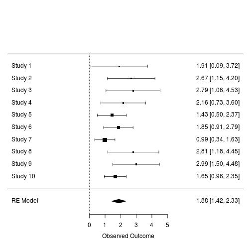

```r
forest(m)
```

### Analysis: Funnel plot

`835` studies with 1 effect size each

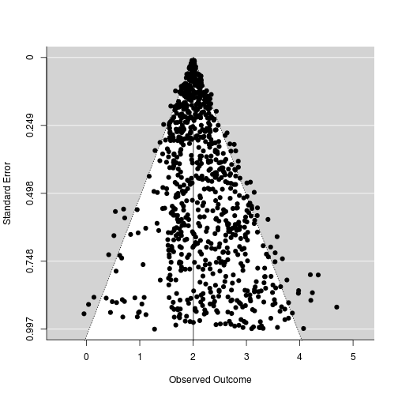

```r
m<-rma(effect_size~1, sei = st_err)
funnel(m)
```

### A more realistic model

- Ecological data is usually more complex –> mixed-effects models
- rma.mv(log_body_size ~ temperature, V = st_err, random =~ temperature|family\genus)
- produces effect + CI + credible interval
- quite new, still experimental
- p-values are wrong (df does not account for nesting)
- I², H² calculation difficult (see metafor website for solution)

### Writing

- Reporting standards are different from standard publications (rigour, objectivity, transparency!), so the methods section includes much more detail
- A good example with proper reporting is https://onlinelibrary.wiley.com/doi/pdf/10.1111/ele.12934 (Ecology Letters)

### sources

GUIDELINES for SYSTEMATIC REVIEWS in ENVIRONMENTAL MANAGEMENT, collaboration for environmental evidence meta-analyises in ecology and evolution